# DEPLOYMENT READINESS ASSESSMENT

**What this section does:**

A technically strong model can still cause harm if deployed badly. This section examines what responsible deployment of this specific model would require before it could be safely put into production.

We do not have a live deployment environment to audit here. PaySim is a static historical dataset. What we can do is assess threshold sensitivity on the existing predictions and produce a clear prescriptive framework for what any institution deploying this model would need to address.

This section is presented as a deployment readiness checklist and a threshold sensitivity analysis. Both are directly required under BoG CISD 2026 §100.

```python
# ── SECTION 1: LOAD CHECKPOINT ───────────────────────────────────────────────

import pandas as pd
import joblib
import shap
import numpy as np
from scipy import stats
from sklearn.preprocessing import LabelEncoder
from scipy.stats import ks_2samp
from fairlearn.metrics import demographic_parity_difference, equalized_odds_difference
from sklearn.metrics import matthews_corrcoef, log_loss, confusion_matrix, precision_recall_curve, auc, confusion_matrix
import matplotlib.pyplot as plt
import seaborn as sns
bins_proxy   = [-np.inf, 0.0, 50397.0, np.inf]
labels_proxy = ['Low-Balance', 'Mid-Balance', 'High-Balance']

df = pd.read_csv('checkpoint.csv')

print(f'Checkpoint loaded: {df.shape[0]:,} rows x {df.shape[1]} columns')
print(df.columns.tolist())
```

```
Checkpoint loaded: 6,362,620 rows x 11 columns
['step', 'type', 'amount', 'nameOrig', 'oldbalanceOrg', 'newbalanceOrig', 'nameDest', 'oldbalanceDest', 'newbalanceDest', 'isFraud', 'isFlaggedFraud']
```

```python
model = joblib.load("xgb_model.pkl")

X_test = pd.read_csv('X_test.csv')
y_test = pd.read_csv('y_test.csv')
results = pd.read_csv('model_results.csv')

y_pred = results['y_pred']
y_prob = results['y_prob']

s_test = results[['balance_group', 'tx_type_group']].astype(str)

print("Model + data loaded")
print(X_test.shape)
```

```
Model + data loaded
(1272524, 6)
```

```python
FEATURES = [
    'step', 'amount', 'oldbalanceOrg', 'newbalanceOrig',
    'oldbalanceDest', 'newbalanceDest'
]
```

```python
# ── SECTION 11: THRESHOLD SENSITIVITY ─────────────────────────────────────────
# The default threshold for classification is 0.5.
# A bank might want to be more aggressive (lower threshold = catch more fraud, more false alarms)
# or more conservative (higher threshold = fewer false alarms, more fraud missed).
# We test a range of thresholds and show how key metrics change.

print('Threshold Sensitivity Analysis')
print('Showing how performance changes at different decision thresholds.\n')

thresholds_to_test = [0.1, 0.2, 0.3, 0.4, 0.5, 0.6, 0.7, 0.8, 0.9]
results_thresh = []

for t in thresholds_to_test:
    # Convert probabilities into binary predictions at threshold t
    y_pred_t = (y_prob >= t).astype(int)

    # Skip degenerate cases (all 0 or all 1 predictions)
    if y_pred_t.sum() == 0:
        continue

    # Global performance metrics
    tn_t, fp_t, fn_t, tp_t = confusion_matrix(y_test, y_pred_t).ravel()

    prec_t = tp_t / (tp_t + fp_t) if (tp_t + fp_t) > 0 else 0
    rec_t  = tp_t / (tp_t + fn_t) if (tp_t + fn_t) > 0 else 0
    mcc_t  = matthews_corrcoef(y_test, y_pred_t)

    # ── Low-Balance fairness metric (TPR) ────────────────────────────────
    lb_mask = s_test['balance_group'].astype(str) == 'Low-Balance'

    lb_yt = y_test[lb_mask].to_numpy().flatten()
    lb_yp = y_pred_t[lb_mask].to_numpy().flatten()

    lb_tp = int(((lb_yt == 1) & (lb_yp == 1)).sum())
    lb_fn = int(((lb_yt == 1) & (lb_yp == 0)).sum())

    lb_tpr = lb_tp / (lb_tp + lb_fn) if (lb_tp + lb_fn) > 0 else 0

    # Store results
    results_thresh.append({
        'threshold': t,
        'precision': prec_t,
        'recall': rec_t,
        'mcc': mcc_t,
        'fp': fp_t,
        'fn': fn_t,
        'lb_tpr': lb_tpr
    })

# Convert results to DataFrame
df_thresh = pd.DataFrame(results_thresh)

# Display results
print(f'{"Threshold":>10} {"Precision":>10} {"Recall":>8} {"MCC":>8} '
      f'{"FP":>8} {"FN":>8} {"LB TPR":>10}')
print('-' * 70)

for _, row in df_thresh.iterrows():
    print(f'{row["threshold"]:>10.1f} {row["precision"]:>10.4f} '
          f'{row["recall"]:>8.4f} {row["mcc"]:>8.4f} '
          f'{int(row["fp"]):>8,} {int(row["fn"]):>8,} {row["lb_tpr"]:>10.4f}')

print('\nLB TPR = True Positive Rate for Low-Balance users at each threshold.')
print('Note how lowering the threshold improves Low-Balance protection')
print('and what cost it introduces in false positives.')
```

```
Threshold Sensitivity Analysis
Showing how performance changes at different decision thresholds.

 Threshold  Precision   Recall      MCC       FP       FN     LB TPR
----------------------------------------------------------------------
       0.1     0.0843   0.9988   0.2881   17,828        2     0.8333
       0.2     0.1159   0.9976   0.3383   12,506        4     0.6667
       0.3     0.1458   0.9976   0.3799    9,606        4     0.6667
       0.4     0.1714   0.9976   0.4122    7,923        4     0.6667
       0.5     0.1977   0.9927   0.4419    6,617       12     0.6667
       0.6     0.2286   0.9903   0.4748    5,489       16     0.6667
       0.7     0.2716   0.9878   0.5170    4,353       20     0.5000
       0.8     0.3362   0.9830   0.5741    3,189       28     0.5000
       0.9     0.4557   0.9696   0.6641    1,903       50     0.1667

LB TPR = True Positive Rate for Low-Balance users at each threshold.
Note how lowering the threshold improves Low-Balance protection
and what cost it introduces in false positives.
```

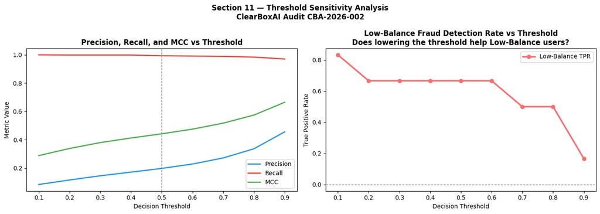

```python
# ── SECTION 11: THRESHOLD CHART ───────────────────────────────────────────────
fig, axes = plt.subplots(1, 2, figsize=(14, 5))
fig.suptitle(
    'Section 11 — Threshold Sensitivity Analysis\n'
    'ClearBoxAI Audit CBA-2026-002',
    fontsize=12, fontweight='bold'
)

axes[0].plot(df_thresh['threshold'], df_thresh['precision'],
             color='#2196F3', lw=2, label='Precision')
axes[0].plot(df_thresh['threshold'], df_thresh['recall'],
             color='#F44336', lw=2, label='Recall')
axes[0].plot(df_thresh['threshold'], df_thresh['mcc'],
             color='#4CAF50', lw=2, label='MCC')
axes[0].set_xlabel('Decision Threshold')
axes[0].set_ylabel('Metric Value')
axes[0].set_title('Precision, Recall, and MCC vs Threshold', fontweight='bold')
axes[0].legend()
axes[0].axvline(0.5, color='gray', linestyle='--', lw=1, label='Default (0.5)')

axes[1].plot(df_thresh['threshold'], df_thresh['lb_tpr'],
             color='#FF6B6B', lw=2.5, marker='o', label='Low-Balance TPR')
axes[1].axhline(0, color='gray', linestyle='--', lw=1)
axes[1].set_xlabel('Decision Threshold')
axes[1].set_ylabel('True Positive Rate')
axes[1].set_title('Low-Balance Fraud Detection Rate vs Threshold\n'
                  'Does lowering the threshold help Low-Balance users?',
                  fontweight='bold')
axes[1].legend()

plt.tight_layout()
plt.savefig('fig_deploy_01_threshold.png', dpi=150, bbox_inches='tight')
plt.show()
```

## [ Deployment readiness findings]

**Threshold Sensitivity:**

The threshold analysis reveals whether the Low-Balance protection gap can be addressed simply by lowering the decision threshold. If Low-Balance TPR improves at lower thresholds, this is a potential short-term mitigation.

The chart reveals something important. Lowering the threshold from 0.5 to 0.1 does improve Low-Balance TPR from 0.6667 to 0.8333. This means threshold adjustment is a partial short-term mitigation, it catches one additional Low-Balance fraud case. However, the cost is significant. False positives jump from 6,617 at threshold 0.5 to 17,828 at threshold 0.1. That is nearly 11,000 additional legitimate customers wrongly blocked for the sake of one extra fraud catch. This tradeoff is not acceptable without a more targeted approach. Threshold adjustment alone does not close the protection gap. It just redistributes the harm.

**Deployment Readiness Checklist:**

Before this model can be deployed in any production environment, the following conditions must be met under BoG CISD 2026:

| Requirement | BoG CISD Reference | Current Status |
| --- | --- | --- |
| Material bias finding addressed | Annexure E §l(i) | NOT MET — EOD = 0.3305 (three times over the 0.10 threshold) |
| BoG notification submitted | §115(2)(b) | REQUIRED |
| Low-Balance fraud coverage remediated | Annexure E §g(iii)(3) | NOT MET |
| Model card completed with bias documentation | Annexure E §j(ii) | IN PROGRESS |
| Human oversight mechanism defined | §100 Annexure E §k | NOT MET |
| Kill-switch capability implemented | Annexure E §k(ii) | NOT MET |
| Fairness monitoring plan established | Annexure E §l(i) | NOT MET |
| Dispute resolution mechanism for AI decisions | Annexure E §l(ii) | NOT MET |

**Verdict: Model is not deployment-ready in current form.**

```python
df.to_csv('checkpoint_v2.csv', index=False)
print("Checkpoint v2 saved.")
```

```
Checkpoint v2 saved.
```